# IS 6812 - Group 5 Combined Modeling Submission

```r
tic()
set.seed(123)
#Create Random Forest Train Data set
RF50Tune1.5ds <- clean_train

#Split Data 75% Training 25% Test
RF50Tune1.5dssplit <- initial_split(RF50Tune1.5ds, strata = TARGET, prop = 0.75)
RF50Tune1.5dstrain <- training(RF50Tune1.5dssplit)
RF50Tune1.5dstest <- testing(RF50Tune1.5dssplit)

#Create Recipe with 1.5 Downsample
RF50Tune1.5dsrecipe <- recipe(TARGET ~ ., data = RF50Tune1.5dstrain) %>% step_downsample(TARGET, under_ratio = 1.5)

#Create Model with Hyperperameter Tuning (Set Perameters based on tuning to save run time)
RF50Tune1.5dsmodel <- rand_forest(
  mtry = (2),
  trees = (727),
  min_n = (31)) %>%
  set_mode("classification") %>%
  set_engine("ranger")

#Set 5 fold CV
RF50Tune1.5dsfolds <- vfold_cv(RF50Tune1.5dstrain, v=5)

doParallel::registerDoParallel(cores = 8)

#Create Workflow
RF50Tune1.5ds_WF <- workflow () %>%
    add_model(RF50Tune1.5dsmodel) %>%
    add_recipe(RF50Tune1.5dsrecipe)

#Tune Model with grid = 50 (very time intensive)
# 50 Grid gives mtry (2), trees (727), min_n (31)
#RF50Tune1.5ds_tune <- RF50Tune1.5ds_WF %>% tune_grid( resamples = RF50Tune1.5dsfolds, grid = 50)

#Create Best model using ROC_AUC
#best_modelRF50Tune1.5ds <- RF50Tune1.5ds_tune %>% select_best ("roc_auc")
#best_modelRF50Tune1.5ds

#Create final WF based on best model
finalWFRF50Tune1.5dsmodel <- RF50Tune1.5ds_WF %>% finalize_workflow(RF50Tune1.5dsmodel)

#Create final fit
final_fitRF50Tune1.5dsmodel <- finalWFRF50Tune1.5dsmodel %>% last_fit(split = RF50Tune1.5dssplit)

#Run Final Fit
final_fitRF50Tune1.5dsmodel %>% collect_metrics()
```

```
## # A tibble: 2 × 4
##   .metric  .estimator .estimate .config
##   <chr>    <chr>          <dbl> <chr>
## 1 accuracy binary         0.814 Preprocessor1_Model1
## 2 roc_auc  binary         0.743 Preprocessor1_Model1
```

```r
#Create Confusion matrix
final_fitRF50Tune1.5dsmodel %>%
  collect_predictions()%>%
  conf_mat(truth = TARGET, estimate = .pred_class)
```

```
##           Truth
## Prediction    No   Yes
##        No  59744  3257
##        Yes 11023  2853
```

```r
#extract WF
final_wfRF50Tune1.5dsmodel <- final_fitRF50Tune1.5dsmodel %>%
  extract_workflow()
final_wfRF50Tune1.5dsmodel
```

```
## ══ Workflow [trained] ══════════════════════════════════════════════════════════
## Preprocessor: Recipe
## Model: rand_forest()
##
## ── Preprocessor ────────────────────────────────────────────────────────────────
## 1 Recipe Step
##
## • step_downsample()
##
## ── Model ───────────────────────────────────────────────────────────────────────
## Ranger result
##
## Call:
##  ranger::ranger(x = maybe_data_frame(x), y = y, mtry = min_cols(~(2),      x), num.trees = ~(727), min.node.size = min_rows(~(31), x),      num.threads = 1, verbose = FALSE, seed = sample.int(10^5,          1), probability = TRUE)
##
## Type:                             Probability estimation
## Number of trees:                  727
## Sample size:                      46787
## Number of independent variables:  23
## Mtry:                             2
## Target node size:                 31
## Variable importance mode:         none
## Splitrule:                        gini
## OOB prediction error (Brier s.):  0.2011711
```

```r
#Predict on test data
RF50Tune1.5dsPred <- predict(final_wfRF50Tune1.5dsmodel, new_data = clean_test, type = 'prob')
#Generate Submission
submission <- data.frame(SK_ID_CURR = as.integer(clean_test$SK_ID_CURR), TARGET = RF50Tune1.5dsPred)
summary(submission)
```

```
##    SK_ID_CURR     TARGET..pred_No  TARGET..pred_Yes
##  Min.   :100001   Min.   :0.1907   Min.   :0.07285
##  1st Qu.:188558   1st Qu.:0.5437   1st Qu.:0.25120
##  Median :277549   Median :0.6580   Median :0.34204
##  Mean   :277797   Mean   :0.6392   Mean   :0.36075
##  3rd Qu.:367556   3rd Qu.:0.7488   3rd Qu.:0.45632
##  Max.   :456250   Max.   :0.9272   Max.   :0.80932
```

```r
submission <- submission %>% rename ("TARGET" = "TARGET..pred_Yes") %>% select(c(SK_ID_CURR, TARGET))
write.csv(submission, file = 'RF50Tune1.5dsmodel.csv', row.names = FALSE)

toc()
```

```
## Elapsed time: 1.04m
```

In this model, an adjustment is made to the tune gird for the first time from 1 to 50 to see what different affects this will have on the data and the ability for our model to make predictions.

```r
tic()
set.seed(123)
#Create Random Forest Train Data set
RF50TuneNods <- clean_train

#Split Data 75% Training 25% Test
RF50TuneNodssplit <- initial_split(RF50TuneNods, strata = TARGET, prop = 0.75)
RF50TuneNodstrain <- training(RF50TuneNodssplit)
RF50TuneNodstest <- testing(RF50TuneNodssplit)

#Create Recipe with 1.5 Downsample
RF50TuneNodsrecipe <- recipe(TARGET ~ ., data = RF50TuneNodstrain)

#Create Model with Hyperperameter Tuning (Set Perameters based on tuning to save run time)
RF50TuneNodsmodel <- rand_forest(
  mtry = (2),
  trees = (727),
  min_n = (31)) %>%
  set_mode("classification") %>%
  set_engine("ranger")

#Set 5 fold CV
RF50TuneNodsfolds <- vfold_cv(RF50TuneNodstrain, v=5)

doParallel::registerDoParallel(cores = 8)

#Create Workflow
RF50TuneNods_WF <- workflow () %>%
    add_model(RF50TuneNodsmodel) %>%
    add_recipe(RF50TuneNodsrecipe)

#Tune Model with grid = 50 (very time intensive)
# 50 Grid gives mtry (2), trees (727), min_n (31)
#RF50TuneNods_tune <- RF50TuneNods_WF %>% tune_grid( resamples = RF50TuneNodsfolds, grid = 50)

#Create Best model using ROC_AUC
#best_modelRF50TuneNods <- RF50TuneNods_tune %>% select_best ("roc_auc")
#best_modelRF50TuneNods

#Create final WF based on best model
finalWFRF50TuneNodsmodel <- RF50TuneNods_WF %>% finalize_workflow(RF50TuneNodsmodel)

#Create final fit
final_fitRF50TuneNodsmodel <- finalWFRF50TuneNodsmodel %>% last_fit(split = RF50TuneNodssplit)

#Run Final Fit
final_fitRF50TuneNodsmodel %>% collect_metrics()
```

```
## # A tibble: 2 × 4
##   .metric  .estimator .estimate .config
##   <chr>    <chr>          <dbl> <chr>
## 1 accuracy binary         0.921 Preprocessor1_Model1
## 2 roc_auc  binary         0.738 Preprocessor1_Model1
```

```r
#Create Confusion matrix
final_fitRF50TuneNodsmodel %>%
  collect_predictions()%>%
  conf_mat(truth = TARGET, estimate = .pred_class)
```

```
##           Truth
## Prediction    No   Yes
##        No  70767  6107
##        Yes     0     3
```

```r
#extract WF
final_wfRF50TuneNodsmodel <- final_fitRF50TuneNodsmodel %>%
  extract_workflow()
final_wfRF50TuneNodsmodel
```

```
## ══ Workflow [trained] ══════════════════════════════════════════════════════════
## Preprocessor: Recipe
## Model: rand_forest()
##
## ── Preprocessor ────────────────────────────────────────────────────────────────
## 0 Recipe Steps
##
## ── Model ───────────────────────────────────────────────────────────────────────
## Ranger result
##
## Call:
##  ranger::ranger(x = maybe_data_frame(x), y = y, mtry = min_cols(~(2),      x), num.trees = ~(727), min.node.size = min_rows(~(31), x),      num.threads = 1, verbose = FALSE, seed = sample.int(10^5,          1), probability = TRUE)
##
## Type:                             Probability estimation
## Number of trees:                  727
## Sample size:                      230630
## Number of independent variables:  23
## Mtry:                             2
## Target node size:                 31
## Variable importance mode:         none
## Splitrule:                        gini
## OOB prediction error (Brier s.):  0.06935129
```

```r
#Predict on test data
RF50TuneNodsPred <- predict(final_wfRF50TuneNodsmodel, new_data = clean_test, type = 'prob')
#Generate Submission
submission <- data.frame(SK_ID_CURR = as.integer(clean_test$SK_ID_CURR), TARGET = RF50TuneNodsPred)
summary(submission)
```

```
##    SK_ID_CURR     TARGET..pred_No  TARGET..pred_Yes
##  Min.   :100001   Min.   :0.5009   Min.   :0.006454
##  1st Qu.:188558   1st Qu.:0.8925   1st Qu.:0.042842
##  Median :277549   Median :0.9329   Median :0.067132
##  Mean   :277797   Mean   :0.9161   Mean   :0.083926
##  3rd Qu.:367556   3rd Qu.:0.9572   3rd Qu.:0.107533
##  Max.   :456250   Max.   :0.9935   Max.   :0.499068
```

```r
submission <- submission %>% rename ("TARGET" = "TARGET..pred_Yes") %>% select(c(SK_ID_CURR, TARGET))
write.csv(submission, file = 'RF50TuneNodsmodel.csv', row.names = FALSE)

toc()
```

```
## Elapsed time: 5.94m
```

In this model we want to see what the results of the Random Forest Model are maintaining the Tune Grid at 50 while going from 1.5 downsample to No downsample

```r
tic()
set.seed(123)
#Create Random Forest Train Data set
RF100Tune1.5ds <- clean_train

#Split Data 75% Training 25% Test
RF100Tune1.5dssplit <- initial_split(RF100Tune1.5ds, strata = TARGET, prop = 0.75)
RF100Tune1.5dstrain <- training(RF100Tune1.5dssplit)
RF100Tune1.5dstest <- testing(RF100Tune1.5dssplit)

#Create Recipe with 1.5 Downsample
RF100Tune1.5dsrecipe <- recipe(TARGET ~ ., data = RF100Tune1.5dstrain) %>% step_downsample(TARGET, under_ratio = 1.5)

#Create Model with Hyperperameter Tuning (Set Perameters based on tuning to save run time)
RF100Tune1.5dsmodel <- rand_forest(
  mtry = (2),
  trees = (1003),
  min_n = (33)) %>%
  set_mode("classification") %>%
  set_engine("ranger")

#Set 5 fold CV
RF100Tune1.5dsfolds <- vfold_cv(RF100Tune1.5dstrain, v=5)

doParallel::registerDoParallel(cores = 8)

#Create Workflow
RF100Tune1.5ds_WF <- workflow () %>%
    add_model(RF100Tune1.5dsmodel) %>%
    add_recipe(RF100Tune1.5dsrecipe)

#Tune Model with grid = 50 (very time intensive)
# 100 Grid gives mtry (2) trees (1003) min_n (33)
#RF100Tune1.5ds_tune <- RF100Tune1.5ds_WF %>% tune_grid( resamples = RF100Tune1.5dsfolds, grid = 100)

#Create Best model using ROC_AUC
#best_modelRF100Tune1.5ds <- RF100Tune1.5ds_tune %>% select_best ("roc_auc")
#best_modelRF100Tune1.5ds

#Create final WF based on best model
finalWFRF100Tune1.5dsmodel <- RF100Tune1.5ds_WF %>% finalize_workflow(RF100Tune1.5dsmodel)

#Create final fit
final_fitRF100Tune1.5dsmodel <- finalWFRF100Tune1.5dsmodel %>% last_fit(split = RF100Tune1.5dssplit)

#Run Final Fit
final_fitRF100Tune1.5dsmodel %>% collect_metrics()
```

```
## # A tibble: 2 × 4
##   .metric  .estimator .estimate .config
##   <chr>    <chr>          <dbl> <chr>
## 1 accuracy binary         0.815 Preprocessor1_Model1
## 2 roc_auc  binary         0.743 Preprocessor1_Model1
```

```r
#Create Confusion matrix
final_fitRF100Tune1.5dsmodel %>%
  collect_predictions()%>%
  conf_mat(truth = TARGET, estimate = .pred_class)
```

```
##           Truth
## Prediction    No   Yes
##        No  59845  3271
##        Yes 10922  2839
```

```r
#extract WF
final_wfRF100Tune1.5dsmodel <- final_fitRF100Tune1.5dsmodel %>%
  extract_workflow()
final_wfRF100Tune1.5dsmodel
```

```
## ══ Workflow [trained] ══════════════════════════════════════════════════════════
## Preprocessor: Recipe
## Model: rand_forest()
##
## ── Preprocessor ────────────────────────────────────────────────────────────────
## 1 Recipe Step
##
## • step_downsample()
##
## ── Model ───────────────────────────────────────────────────────────────────────
## Ranger result
##
## Call:
##  ranger::ranger(x = maybe_data_frame(x), y = y, mtry = min_cols(~(2),      x), num.trees = ~(1003), min.node.size = min_rows(~(33),      x), num.threads = 1, verbose = FALSE, seed = sample.int(10^5,      1), probability = TRUE)
##
## Type:                             Probability estimation
## Number of trees:                  1003
## Sample size:                      46787
## Number of independent variables:  23
## Mtry:                             2
## Target node size:                 33
## Variable importance mode:         none
## Splitrule:                        gini
## OOB prediction error (Brier s.):  0.2010897
```

```r
#Predict on test data
RF100Tune1.5dsPred <- predict(final_wfRF100Tune1.5dsmodel, new_data = clean_test, type = 'prob')
#Generate Submission
submission <- data.frame(SK_ID_CURR = as.integer(clean_test$SK_ID_CURR), TARGET = RF100Tune1.5dsPred)
summary(submission)
```

```
##    SK_ID_CURR     TARGET..pred_No  TARGET..pred_Yes
##  Min.   :100001   Min.   :0.1927   Min.   :0.07193
##  1st Qu.:188558   1st Qu.:0.5437   1st Qu.:0.25194
##  Median :277549   Median :0.6575   Median :0.34252
##  Mean   :277797   Mean   :0.6391   Mean   :0.36087
##  3rd Qu.:367556   3rd Qu.:0.7481   3rd Qu.:0.45626
##  Max.   :456250   Max.   :0.9281   Max.   :0.80735
```

```r
submission <- submission %>% rename ("TARGET" = "TARGET..pred_Yes") %>% select(c(SK_ID_CURR, TARGET))
write.csv(submission, file = 'RF100Tune1.5dsmodel.csv', row.names = FALSE)

toc()
```

```
## Elapsed time: 1.42m
```

For the 5th Random Forest Model, we make the last adjustment to the Tune Grid and set it at 100, and we set the Downsample to 1.5

```r
tic()
set.seed(123)
#Create Random Forest Train Data set
RF100TuneNods <- clean_train

#Split Data 75% Training 25% Test
RF100TuneNodssplit <- initial_split(RF100TuneNods, strata = TARGET, prop = 0.75)
RF100TuneNodstrain <- training(RF100TuneNodssplit)
RF100TuneNodstest <- testing(RF100TuneNodssplit)

#Create Recipe with 1.5 Downsample
RF100TuneNodsrecipe <- recipe(TARGET ~ ., data = RF100TuneNodstrain)

#Create Model with Hyperperameter Tuning (Set Perameters based on tuning to save run time)
RF100TuneNodsmodel <- rand_forest(
  mtry = (2),
  trees = (1003),
  min_n = (33)) %>%
  set_mode("classification") %>%
  set_engine("ranger")

#Set 5 fold CV
RF100TuneNodsfolds <- vfold_cv(RF100TuneNodstrain, v=5)

doParallel::registerDoParallel(cores = 8)

#Create Workflow
RF100TuneNods_WF <- workflow () %>%
    add_model(RF100TuneNodsmodel) %>%
    add_recipe(RF100TuneNodsrecipe)

#Tune Model with grid = 50 (very time intensive)
# 100 Grid gives mtry (2) trees (1003) min_n (33)
#RF100TuneNods_tune <- RF100TuneNods_WF %>% tune_grid( resamples = RF100TuneNodsfolds, grid = 100)

#Create Best model using ROC_AUC
#best_modelRF100TuneNods <- RF100TuneNods_tune %>% select_best ("roc_auc")
#best_modelRF100TuneNods

#Create final WF based on best model
finalWFRF100TuneNodsmodel <- RF100TuneNods_WF %>% finalize_workflow(RF100TuneNodsmodel)

#Create final fit
final_fitRF100TuneNodsmodel <- finalWFRF100TuneNodsmodel %>% last_fit(split = RF100TuneNodssplit)

#Run Final Fit
final_fitRF100TuneNodsmodel %>% collect_metrics()
```

```
## # A tibble: 2 × 4
##   .metric  .estimator .estimate .config
##   <chr>    <chr>          <dbl> <chr>
## 1 accuracy binary         0.921 Preprocessor1_Model1
## 2 roc_auc  binary         0.739 Preprocessor1_Model1
```

```r
#Create Confusion matrix
final_fitRF100TuneNodsmodel %>%
  collect_predictions()%>%
  conf_mat(truth = TARGET, estimate = .pred_class)
```

```
##           Truth
## Prediction    No   Yes
##        No  70767  6109
##        Yes     0     1
```

```r
#extract WF
final_wfRF100TuneNodsmodel <- final_fitRF100TuneNodsmodel %>%
  extract_workflow()
final_wfRF100TuneNodsmodel
```

```
## ══ Workflow [trained] ══════════════════════════════════════════════════════════
## Preprocessor: Recipe
## Model: rand_forest()
##
## ── Preprocessor ────────────────────────────────────────────────────────────────
## 0 Recipe Steps
##
## ── Model ───────────────────────────────────────────────────────────────────────
## Ranger result
##
## Call:
##  ranger::ranger(x = maybe_data_frame(x), y = y, mtry = min_cols(~(2),      x), num.trees = ~(1003), min.node.size = min_rows(~(33),      x), num.threads = 1, verbose = FALSE, seed = sample.int(10^5,      1), probability = TRUE)
##
## Type:                             Probability estimation
## Number of trees:                  1003
## Sample size:                      230630
## Number of independent variables:  23
## Mtry:                             2
## Target node size:                 33
## Variable importance mode:         none
## Splitrule:                        gini
## OOB prediction error (Brier s.):  0.06934515
```

```r
#Predict on test data
RF100TuneNodsPred <- predict(final_wfRF100TuneNodsmodel, new_data = clean_test, type = 'prob')
#Generate Submission
submission <- data.frame(SK_ID_CURR = as.integer(clean_test$SK_ID_CURR), TARGET = RF100TuneNodsPred)
summary(submission)
```

```
##    SK_ID_CURR     TARGET..pred_No  TARGET..pred_Yes
##  Min.   :100001   Min.   :0.5153   Min.   :0.009013
##  1st Qu.:188558   1st Qu.:0.8924   1st Qu.:0.042812
##  Median :277549   Median :0.9329   Median :0.067126
##  Mean   :277797   Mean   :0.9161   Mean   :0.083853
##  3rd Qu.:367556   3rd Qu.:0.9572   3rd Qu.:0.107647
##  Max.   :456250   Max.   :0.9910   Max.   :0.484714
```

```r
submission <- submission %>% rename ("TARGET" = "TARGET..pred_Yes") %>% select(c(SK_ID_CURR, TARGET))
write.csv(submission, file = 'RF100TuneNodsmodel.csv', row.names = FALSE)

toc()
```

```
## Elapsed time: 8.42m
```

For our last model, we compare how the model does with the Tune Grid set to 100 and no downsample. This is the last of our Random Forest Models and it is now time to view and compare the metrics to evaluate model performance

### Model Performance

```r
#1 Tune Grid 1.5 DS Results
final_fitRF1Tune1.5dsmodel %>% collect_metrics()
```

```
## # A tibble: 2 × 4
##   .metric  .estimator .estimate .config
##   <chr>    <chr>          <dbl> <chr>
## 1 accuracy binary         0.921 Preprocessor1_Model1
## 2 roc_auc  binary         0.723 Preprocessor1_Model1
```

```r
final_fitRF1Tune1.5dsmodel %>%
  collect_predictions()%>%
  conf_mat(truth = TARGET, estimate = .pred_class)
```

```
##           Truth
## Prediction    No   Yes
##        No  70693  6031
##        Yes    74    79
```

```r
#1 Tune Grid No DS Results
final_fitRF1TuneNodsmodel %>% collect_metrics()
```

```
## # A tibble: 2 × 4
##   .metric  .estimator .estimate .config
##   <chr>    <chr>          <dbl> <chr>
## 1 accuracy binary         0.790 Preprocessor1_Model1
## 2 roc_auc  binary         0.734 Preprocessor1_Model1
```

```r
final_fitRF1TuneNodsmodel %>%
  collect_predictions()%>%
  conf_mat(truth = TARGET, estimate = .pred_class)
```

```
##           Truth
## Prediction    No   Yes
##        No  57622  3010
##        Yes 13145  3100
```

```r
#50 Tune Grid 1.5 DS Results
final_fitRF50Tune1.5dsmodel %>% collect_metrics()
```

```
## # A tibble: 2 × 4
##   .metric  .estimator .estimate .config
##   <chr>    <chr>          <dbl> <chr>
## 1 accuracy binary         0.814 Preprocessor1_Model1
## 2 roc_auc  binary         0.743 Preprocessor1_Model1
```

```r
final_fitRF50Tune1.5dsmodel %>%
  collect_predictions()%>%
  conf_mat(truth = TARGET, estimate = .pred_class)
```

```
##           Truth
## Prediction    No   Yes
##        No  59744  3257
##        Yes 11023  2853
```

```r
#50 Tune Grid No DS Results
final_fitRF50TuneNodsmodel %>% collect_metrics()
```

```
## # A tibble: 2 × 4
##   .metric  .estimator .estimate .config
##   <chr>    <chr>          <dbl> <chr>
## 1 accuracy binary         0.921 Preprocessor1_Model1
## 2 roc_auc  binary         0.738 Preprocessor1_Model1
```

```r
final_fitRF50TuneNodsmodel %>%
  collect_predictions()%>%
  conf_mat(truth = TARGET, estimate = .pred_class)
```

```
##           Truth
## Prediction    No   Yes
##        No  70767  6107
##        Yes     0     3
```

```r
#100 Tune Grid 1.5 DS Results
final_fitRF100Tune1.5dsmodel %>% collect_metrics()
```

```
## # A tibble: 2 × 4
##   .metric  .estimator .estimate .config
##   <chr>    <chr>          <dbl> <chr>
## 1 accuracy binary         0.815 Preprocessor1_Model1
## 2 roc_auc  binary         0.743 Preprocessor1_Model1
```

```r
final_fitRF100Tune1.5dsmodel %>%
  collect_predictions()%>%
  conf_mat(truth = TARGET, estimate = .pred_class)
```

```
##           Truth
## Prediction    No   Yes
##        No  59845  3271
##        Yes 10922  2839
```

```r
#100 Tune Grid No DS Results
final_fitRF100TuneNodsmodel %>% collect_metrics()
```

```
## # A tibble: 2 × 4
##   .metric  .estimator .estimate .config
##   <chr>    <chr>          <dbl> <chr>
## 1 accuracy binary         0.921 Preprocessor1_Model1
## 2 roc_auc  binary         0.739 Preprocessor1_Model1
```

```r
final_fitRF100TuneNodsmodel %>%
  collect_predictions()%>%
  conf_mat(truth = TARGET, estimate = .pred_class)
```

```
##           Truth
## Prediction    No   Yes
##        No  70767  6109
##        Yes     0     1
```

Viewing the results of the 6 models together and comparing results to see which of the Random Forest Models is best.

#### Summary

This is a great model with a very good AUC score. A couple of drawbacks to this model that ultimately lead us to not make this our preferred model is the large amount of time that it takes to run these models, as well it being a blackbox method and being more difficult to explain how the predictions are made.

## Model 3

The third model that we built was the Extreme Gradient Boosting model. While it ultimately was not the model we chose, it was another model that did well and had Kaggle Scores above .71, which is very comparable to the model that we selected

### Data Preparation

Preparing the dataframes that we will use for training and testing this model

#### Class Imbalance visualization

```r
# Computing and visualizing the class imbalance in the clean_train data set using a bar chart.
table(clean_train$TARGET)
```

```
##
##      0      1
## 282682  24825
```

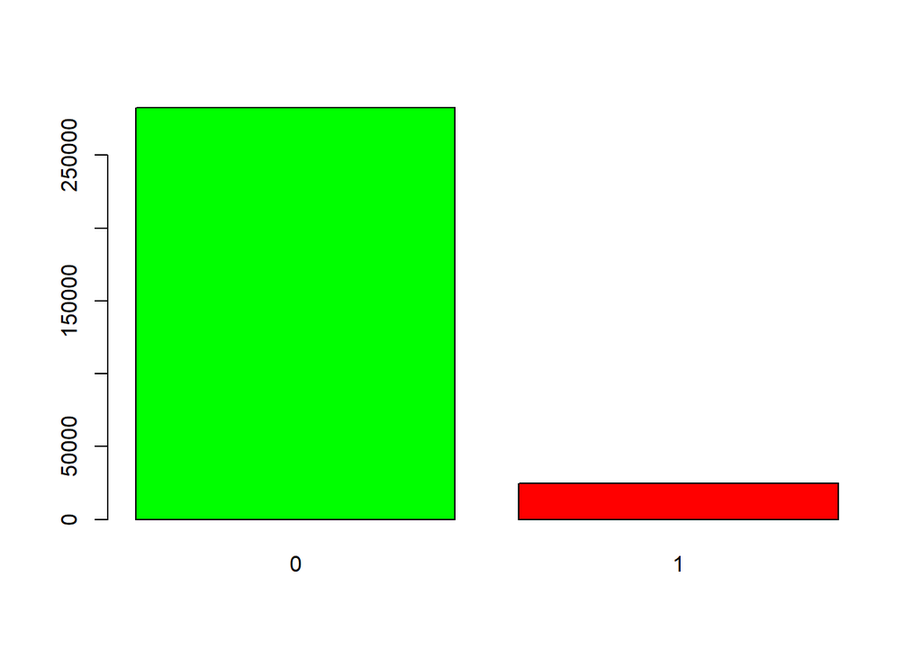

```r
#Plot a bar chart to view the class imbalance
barplot(table(clean_train$TARGET),
        col = c('green', 'red'))
```

This visualization shows that imbalance that exists in the target variable.

```
##     model        parameter                          label forReg forClass
## 1 xgbTree          nrounds          # Boosting Iterations   TRUE     TRUE
## 2 xgbTree        max_depth                 Max Tree Depth   TRUE     TRUE
## 3 xgbTree              eta                      Shrinkage   TRUE     TRUE
## 4 xgbTree            gamma         Minimum Loss Reduction   TRUE     TRUE
## 5 xgbTree colsample_bytree     Subsample Ratio of Columns   TRUE     TRUE
## 6 xgbTree min_child_weight Minimum Sum of Instance Weight   TRUE     TRUE
## 7 xgbTree        subsample           Subsample Percentage   TRUE     TRUE
##   probModel
## 1      TRUE
## 2      TRUE
## 3      TRUE
## 4      TRUE
## 5      TRUE
## 6      TRUE
## 7      TRUE
```

Setting up a cross validation function that we will be able to use moving forward to Gradient Boosting Models

#### Adaptive Search

[output not shown]

Setting up an additional cross validation function using the adaptive search method

#### Grid Search

```r
#Performs grid search for hyper-parameter tuning using an expanded grid of parameters.
set.seed(123)
cv <- trainControl(method = "repeatedcv",
                   number = 3,
                   repeats = 2,
                   allowParallel = T,
                   verboseIter = T,
                   returnData = F,
                   sampling = 'up')

g <- expand.grid(nrounds = seq(from = 400, to = 600, by =5),
                 max_depth = 2,
                 eta = seq(from =0.0200, to = 0.0205, by = 0.0001),
                 gamma = 6.68,
                 colsample_bytree = 0.476,
                 min_child_weight = 1,
                 subsample = 0.328)
```

### Modeling Process

#### Model Training

```
## Fitting nrounds = 600, max_depth = 2, eta = 0.0204, gamma = 6.68, colsample_bytree = 0.476, min_child_weight = 1, subsample = 0.328 on full training set
```

```
## Elapsed time: 5.65m
```

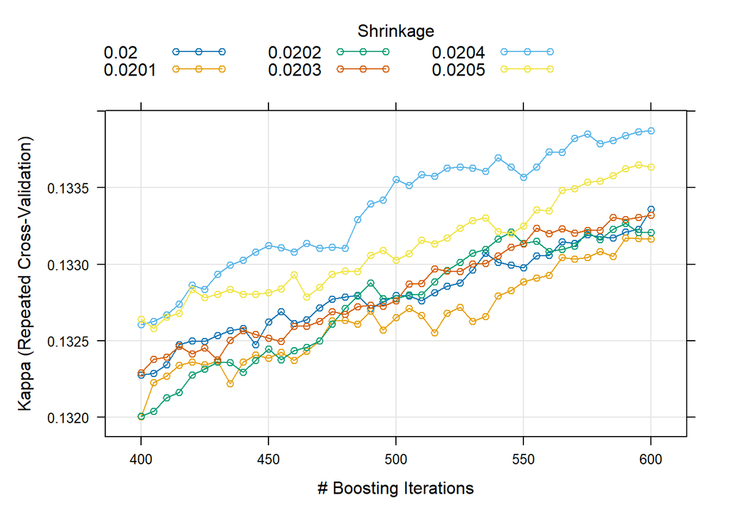

Setting oup our initial model where we train the Gradient Boosting model on the training data that we split out of our data

### Model Performance

#### Confusion Matrix Evaluation

```r
#Computes confusion matrices for the train and test data sets using the trained model.
p <- predict(model, newdata = train, 'raw')
(tab <- table(predicted = p, Actual = train$TARGET))
```

```
##          Actual
## predicted      0      1
##         0 153504   6680
##         1  72445  13151
```

```r
p1 <- predict(model, newdata = test, 'raw')
(tab1 <- table(predicted = p1, Actual = test$TARGET))
```

```
##          Actual
## predicted     0     1
##         0 38636  1643
##         1 18097  3351
```

Here we can evaluate the performance via a confusion matrix for the train and test data that we split from our data set, comparing the predictions to actual results

```r
# Confusion matrix for training data
p <- predict(model, newdata = train, 'raw')
(tab_train <- table(predicted = p, Actual = train$TARGET))
```

```
##          Actual
## predicted      0      1
##         0 153504   6680
##         1  72445  13151
```

```r
# Confusion matrix for test data
p1 <- predict(model, newdata = test, 'raw')
(tab_test <- table(predicted = p1, Actual = test$TARGET))
```

```
##          Actual
## predicted     0     1
##         0 38636  1643
##         1 18097  3351
```

```r
# Calculate Accuracy
accuracy_train <- (tab_train[1] + tab_train[4]) / sum(tab_train)
accuracy_test <- (tab_test[1] + tab_test[4]) / sum(tab_test)


# Calculate Precision, Recall, and F1-score for training data
precision_train <- tab_train[4] / (tab_train[4] + tab_train[2])
recall_train <- tab_train[4] / (tab_train[4] + tab_train[3])
f1_train <- 2 * (precision_train * recall_train) / (precision_train + recall_train)


# Calculate Precision, Recall, and F1-score for test data
precision_test <- tab_test[4] / (tab_test[4] + tab_test[2])
recall_test <- tab_test[4] / (tab_test[4] + tab_test[3])
f1_test <- 2 * (precision_test * recall_test) / (precision_test + recall_test)


# ROC curve and AUC for training data
library(pROC)
p <- as.numeric(p)
roc_train <- roc(response = train$TARGET, predictor = p)
auc_train <- auc(roc_train)

# ROC curve and AUC for test data
p1 <- as.numeric(p1)
roc_test <- roc(response = test$TARGET, predictor = p1)
auc_test <- auc(roc_test)
```

```r
# Output the Model Metrics
cat("Model Metrics:\n")
```

```
## Model Metrics:
```

```r
cat(paste("Accuracy (Training):", accuracy_train, "\n"))
```

```
## Accuracy (Training): 0.678065749857596
```

```r
cat(paste("Accuracy (Test):", accuracy_test, "\n"))
```

```
## Accuracy (Test): 0.680204772627861
```

```r
cat(paste("Precision (Training):", precision_train, "\n"))
```

```
## Precision (Training): 0.153640357026029
```

```r
cat(paste("Precision (Test):", precision_test, "\n"))
```

```
## Precision (Test): 0.156238343901529
```

```r
cat(paste("Recall (Training):", recall_train, "\n"))
```

```
## Recall (Training): 0.663153648328375
```

```r
cat(paste("Recall (Test):", recall_test, "\n"))
```

```
## Recall (Test): 0.671005206247497
```

```r
cat(paste("F1 Score (Training):", f1_train, "\n"))
```

```
## F1 Score (Training): 0.249480683316418
```

```r
cat(paste("F1 Score (Test):", f1_test, "\n"))
```

```
## F1 Score (Test): 0.253460403902882
```

```r
cat(paste("AUC (Training):", auc_train, "\n"))
```

```
## AUC (Training): 0.671264098726146
```

```r
cat(paste("AUC (Test):", auc_test, "\n"))
```

```
## AUC (Test): 0.676009891650708
```

# Other Models

We also considered and attempted to build various other models including C5.0 and Naive Bayes amongst others. We quickly realized that these options were not going to be as successful as many other model types, so we abandoned these and focused more on the models above. We ran into various different issues with these models, such as all predictions being classified as “No”, and as such we chose to focus our efforts on the above models.

# Results

As mentioned above, we decided that the logistic regression model is our best model and the model that we would present to our stakeholders in order to predict payment default among there future customers. We would use the base upsampled version since it is more parsimonious than the slightly better interaction model, but also is less affected by training on unbalanced data.

The logistic model with interactions has an AUC of 0.7326, with the under sampled version having an AUC of 0.7320 and the base 8 important var model with an AUC of 0.7321. The upsampling model without interaction had an AUC of 0.7320 while the oversampled model with interactions had an AUC of 0.7337.

The Kaggle scores for this model were: Private Score: .71388 Public Score: .72379

We had some other models with really similar Kaggle scores and AUC values, but we ultimately felt that using a white box would be important for a company in the lending industry. This will enable the business to explain to any financial regulators how the model works and ensure they are aware of how it could discriminate against potential customers.

# Group Members and Contributions

All group members were engaged in the project and attended the group meetings, participated in discussions, built different models that were tested and generated AUC scores ranging from ~.62-.74. All group members were also involved in a Slack channel where questions were answered and collaborative work was done. Additionally, I have highlighted additional additional contributions specific to each group member below.

Andrew Walton - Built a logistic regression model and compiled the 4 workbooks into one cohesive workbook

Michael Tom: Built a highly successful Random Forest Model, was always done with his assigned work early

Ian Donaldson: Bulit a Logistic Regression model which became our preferred model to recommend to stakeholders. Organized the group by setting up zoom meetings and Slack Channel

Louis Ackumey: Built another vary successful model that had high Kaggle scores. Timely submissions of assigned work